# Visualization of spWAVE results

Kai Li

2024-11-06 (updated 2026-09-24)

In this vignette, we will use the spWAVE output to visualize the results.

## Load the required libraries

```r
library(magrittr)
library(dplyr)
library(tidyr)
library(stringr)

library(Seurat)
library(Matrix)

library(ggplot2)
library(circlize)
library(ComplexHeatmap)
library(igraph)
library(patchwork)

library(spWAVE)
```

## The vector field projection

First, let’s load the saved output data of spWAVE and see the slice and cluster again.

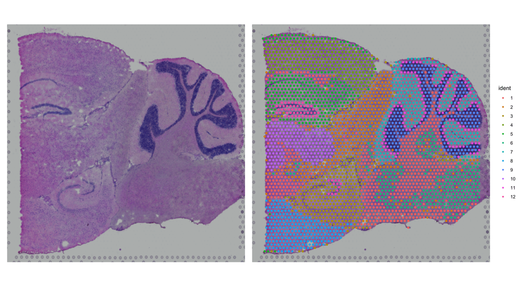

```r
#** folder holding the tutorial datasets, adjust it to your local copy
data_dir <- "../../data"
load(file.path(data_dir, "v2", "spWAVE_vignettes_tiny_data_v2.RData"))
p1 <- SpatialDimPlot(brain,alpha=0) +NoLegend()
p2 <- SpatialDimPlot(brain)
p1|p2
```

In spWAVE, we can plot certain LR interaction field, let’s start with “Fgf1-Fgfr1” without other image and seurat object. We need to extract the LR field info from database result. And we will display two mode of field projection: point mode and grid mode.

```r
brain_Fgf1 <-
  extract_LR_field_result(
    database_result=brain_db_res,
    LR = "Fgf1.Fgfr1",
    kept_db=complex_data$kept_db) %>%
  calc_field_strength()
#** the extracted field holds the Ex/Ey/U planes and the ligand/receptor expression only:
#** unlike the old per-pair tables it carries no coordinates, so take them from `brain_coord`
#** (same barcodes, same order).
brain_Fgf1 <- cbind(brain_coord[rownames(brain_Fgf1), c("x","y","barcode")], brain_Fgf1)
brain_Fgf1 %>% head
```

```
#>                           x        y            barcode            Ex
#> AAACAAGTATCTCCCA-1 6213.208 4607.621 AAACAAGTATCTCCCA-1  4.400470e-04
#> AAACACCAATAACTGC-1 2063.081 3824.797 AAACACCAATAACTGC-1  1.848817e-04
#> AAACAGCTTTCAGAAG-1 1562.742 5216.887 AAACAGCTTTCAGAAG-1  1.311554e-04
#> AAACAGGGTCTATATT-1 1763.168 4868.320 AAACAGGGTCTATATT-1 -7.469621e-05
#> AAACAGTGTTCCTGGG-1 3262.733 2606.265 AAACAGTGTTCCTGGG-1 -1.144690e-04
#> AAACATTTCCCGGATT-1 5963.401 3650.514 AAACATTTCCCGGATT-1 -1.029766e-04
#>                               Ey           U      Fgf1     Fgfr1 Rel_LR_Exp
#> AAACAAGTATCTCCCA-1  0.0002181545  0.14009258 1.3862944 0.6931472  0.6931472
#> AAACACCAATAACTGC-1 -0.0005181574  0.00904740 0.6931472 0.6931472  0.0000000
#> AAACAGCTTTCAGAAG-1  0.0002395317 -0.03772395 1.0986123 0.0000000  1.0986123
#> AAACAGGGTCTATATT-1 -0.0002256145  0.05111014 0.6931472 0.0000000  0.6931472
#> AAACAGTGTTCCTGGG-1  0.0000195163 -0.08352131 0.0000000 0.6931472 -0.6931472
#> AAACATTTCCCGGATT-1 -0.0004868262  0.09508120 0.0000000 1.3862944 -1.3862944
#>                              KEx           KEy   E_strength            KU
#> AAACAAGTATCTCCCA-1  3.501782e-05  1.736018e-05 3.908483e-05  0.0111482131
#> AAACACCAATAACTGC-1  1.471242e-05 -4.123366e-05 4.377979e-05  0.0007199692
#> AAACAGCTTTCAGAAG-1  1.043702e-05  1.906132e-05 2.173167e-05 -0.0030019769
#> AAACAGGGTCTATATT-1 -5.944136e-06 -1.795383e-05 1.891224e-05  0.0040672158
#> AAACAGTGTTCCTGGG-1 -9.109151e-06  1.553058e-06 9.240597e-06 -0.0066464151
#> AAACATTTCCCGGATT-1 -8.194620e-06 -3.874040e-05 3.959761e-05  0.0075663212
```

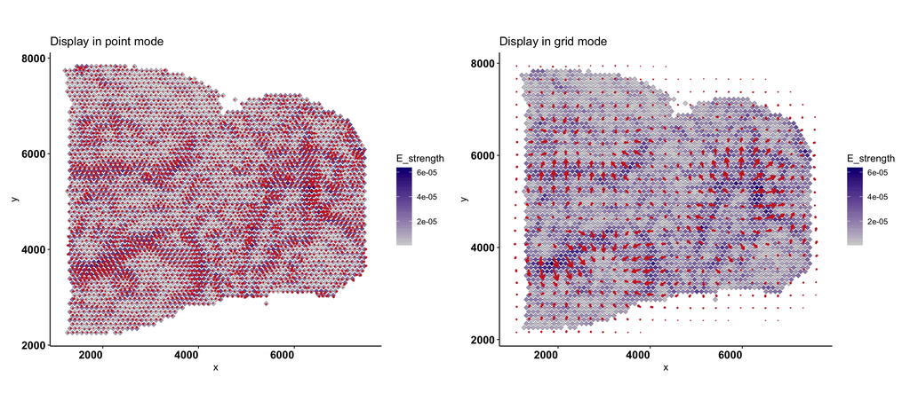

```r
p3 <- plot_field_direction2(brain_Fgf1,point_size = 2,mode="point",arrow_sf=1.5)+
  labs(title = "Display in point mode")
p4 <- plot_field_direction2(brain_Fgf1,point_size = 2,mode="grid")+
  labs(title = "Display in grid mode")
p3+p4
```

Both “point” and “grid” mode show vector field with similar pattern. However, the “point” mode seems cluttered with too many arrows, we recommend using the “grid” mode and it is the defatlt option.

We can specify particular data which is the column names of the data.frame to change the data displayed in the point. With ggplot2 setting, we can give a two-color scale gradiant to display two-directional value.

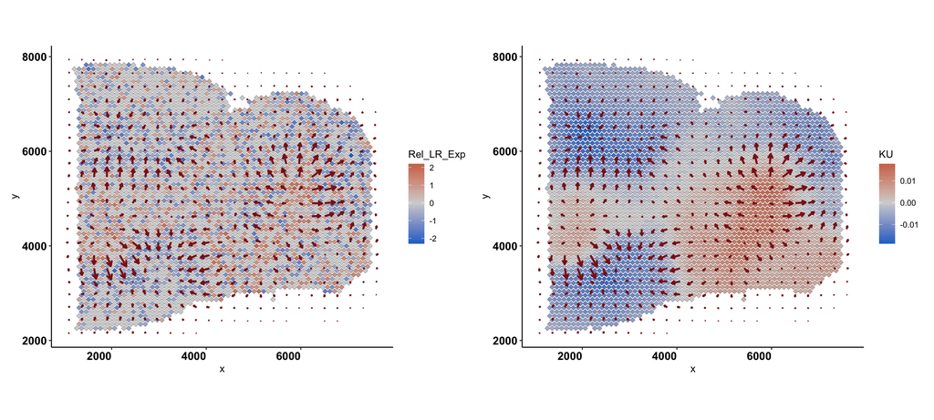

```r
p5 <- plot_field_direction2(brain_Fgf1,point = "Rel_LR_Exp",
        point_size = 2,arrow_color = "firebrick4")+
          scale_fill_gradient2(low="dodgerblue3", mid="lightgray",high="salmon3")
p6 <- plot_field_direction2(brain_Fgf1,point = "KU",
        point_size = 2,arrow_color = "firebrick4")+
          scale_fill_gradient2(low="dodgerblue3", mid="lightgray",high="salmon3")
p5|p6
```

In this figure, the “Rel_LR_Exp” represent the relative Ligand-Recptor expression, which the postive is the ligand and negative is the receptor, repestively. The “KU” is calcuated as the potenital of the field, and matchs with the “Rel_LR_Exp”, displaying the pattern of the LR spatial distribution.

Next, we can plot the field over the HE image or cluster info, by changing the image parameter and giving seurat object, which contains the background info. The cluster infos are extracted from the ‘active.ident’ of the seurat object.

```r
p7 <- plot_field_direction2(brain_Fgf1,
        seurat_obj = brain,
        image="HE",mode='grid'
        ) + NoLegend()
```

```
#> replace the existing one.
```

```r
p8 <- plot_field_direction2(brain_Fgf1,
        seurat_obj = brain,
        image="cluster",mode='grid')
```

```
#> replace the existing one.
```

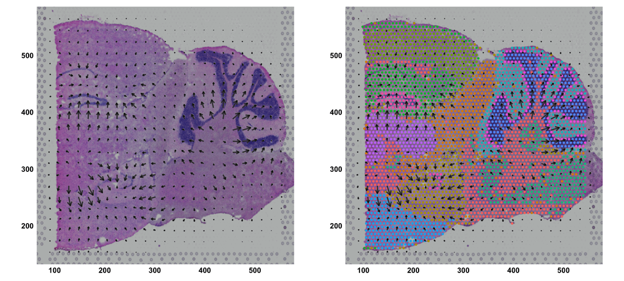

```r
p7|p8
```

Note here, because of the Seurat plotting behavior, the coordinates in plot will change to lo-res image based, to match the Seurat plotting functions.

## Cluster-level Interaction Score Evaluation

After plotting the field over the cluster image, we are curious about how the clusters-level interactions shapes and do them refelect the field projection.

### Dot Plot

Because we use a tiny database only with two LR family, the “TGFb” and “FGF”, the result has less interactions and we can show the whole interacion score using dot plot.

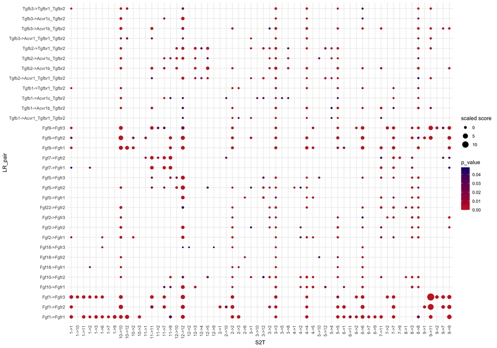

```r
plot_db_score_dot(
  db_C2C_score_list,complex_data$kept_db,
  LR_pair = NULL,
  LR_family = c("TGFb","FGF"),
  source_use = NULL,
  target_use = NULL,
  scale = TRUE
  )
```

For the first time drawing the cluster to cluster (C2C) score plot, we list the all parameter controling the dot content. The “LR_pair” and “LR_family” determine LR pair or family to be displayed. The “source_use” and “target_use” filter which cluster will be used in sender (source) or receiver (target), repestively. The default option “NULL” means not filtering and keeping all results in the parameter. And those parameters are also used in the other plot function and keep the same manners.

Since the whole tiny database give too much info, we can using the filter to narrow down the LR pair and clusters we interested. From the field projection plot, we found the “Fgf1-Fgfr1” interaction is enriched in the area of cluster 7,9,11, with the sender may be the cluster 1,2.

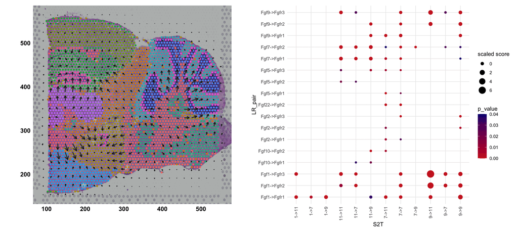

```r
p9 <- plot_db_score_dot(
  db_C2C_score_list,complex_data$kept_db,
  LR_family = c("FGF"),
  source_use = c("1","2","7","9","11"),
  target_use = c("7","9","11"),
  scale = TRUE
  )
p8+p9+plot_layout(width=c(5,4))
```

### Heatmap

Also, we can use heatmap which is more proper to show the sender and receiver relationship.

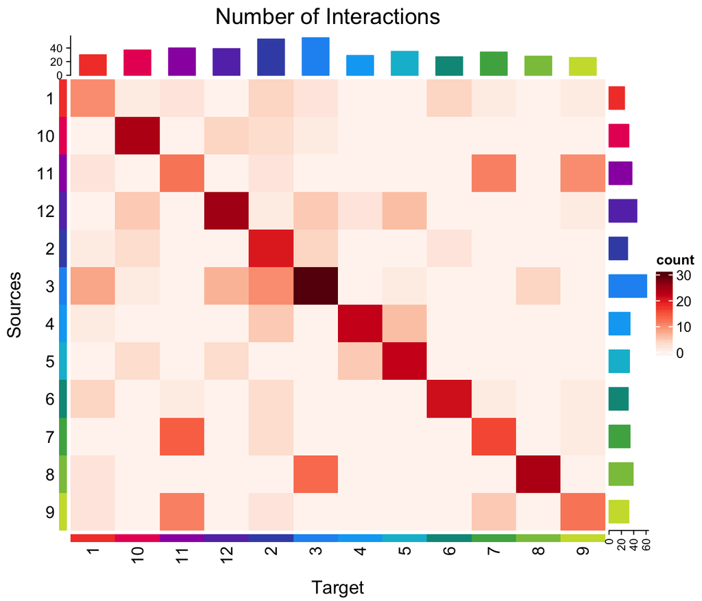

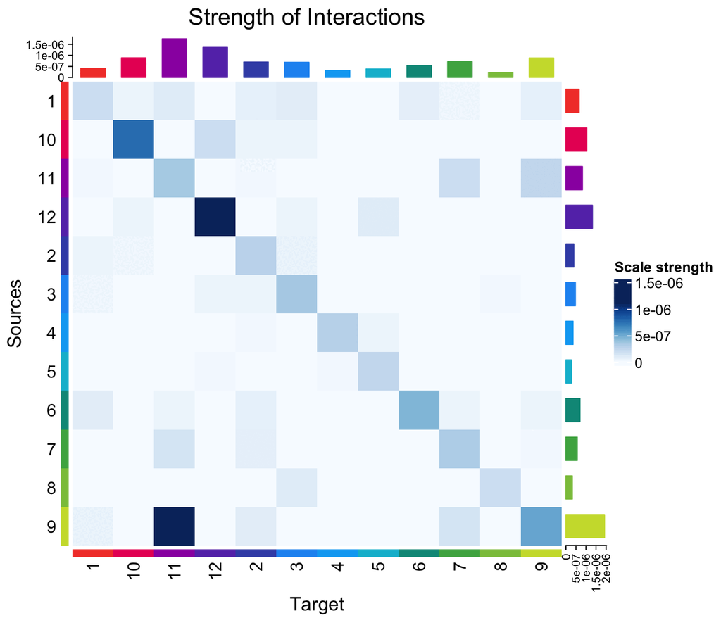

```r
plot_LR_cluster_heatmap(
  db_C2C_score_list,
  complex_data$kept_db,
  #LR_family = "TGFb",
  #LR_pair = c("Fgf1.Fgfr1","Fgf1.Fgfr2"),
  #source_use=c("1","10","11","2","9"),
  #target_use = c("7","9","11","12"),
  method_use="count",
  normalize=FALSE,
  ht_col="Reds"
)
plot_LR_cluster_heatmap(
  db_C2C_score_list,
  complex_data$kept_db,
  #LR_family = "FGF",
  #LR_pair = c("Fgf1.Fgfr1","Fgf1.Fgfr2"),
  #source_use=c("1","10","11","2","9"),
  #target_use = c("7","9","11","12"),
  method_use="strength",
  normalize=TRUE,
  ht_col="Blues"
)
```

As the comment shown, we can filter the cluster and interacion like above. And the parameter “method_use” is used to choose the type of data. The “count” means the number of interactions, while the “strength” means the sum of strength between the clusters.

### Network Diagram

Similarly, we can plot the network using the same parameters.

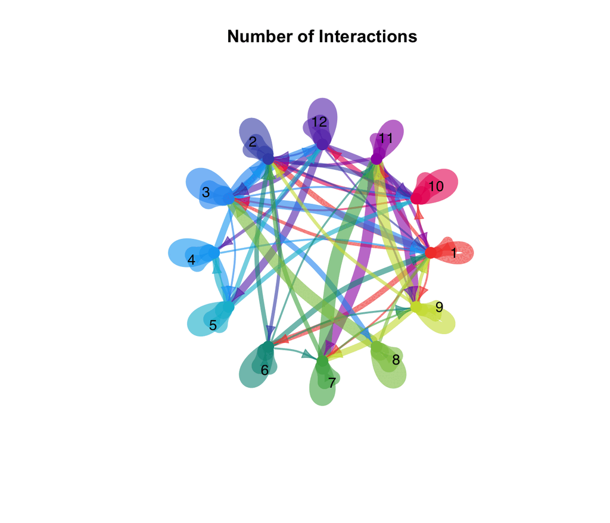

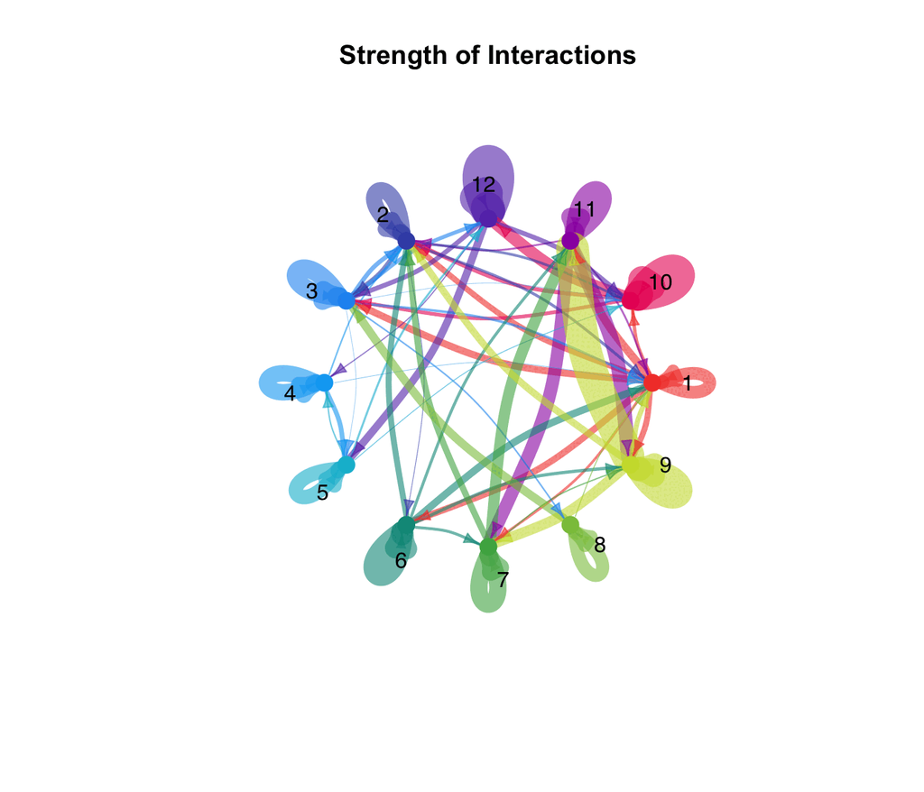

```r
plot_LR_cluster_net(
    db_C2C_score_list,complex_data$kept_db,
      method_use = "count",
      mat_scale = TRUE,
    )
plot_LR_cluster_net(
    db_C2C_score_list,complex_data$kept_db,
      method_use = "strength",
      mat_scale = TRUE,
    )
```

Same like other plot, we can determine the cluster and interacion we interested to show. But here is a little different, we use ‘cluster_use’ instead of ‘source_use’ and ‘target_use’, because there are only node in the network but not the ‘sender’ or ‘recevier’.

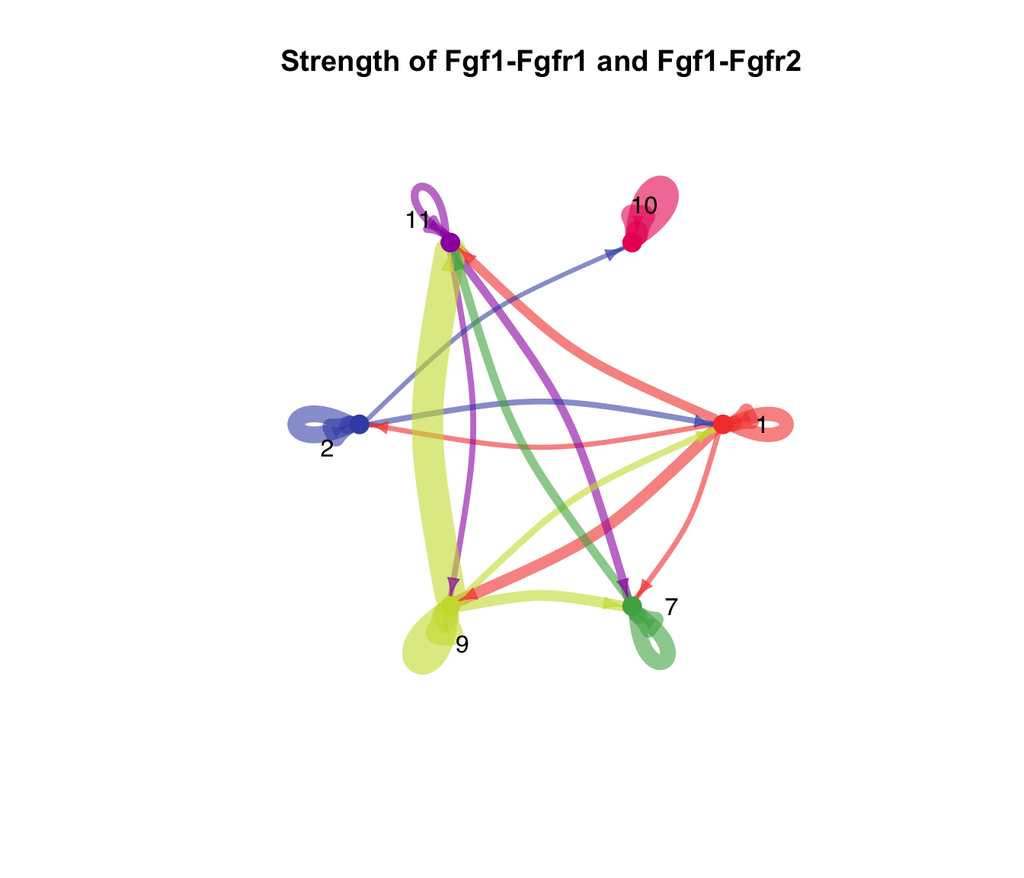

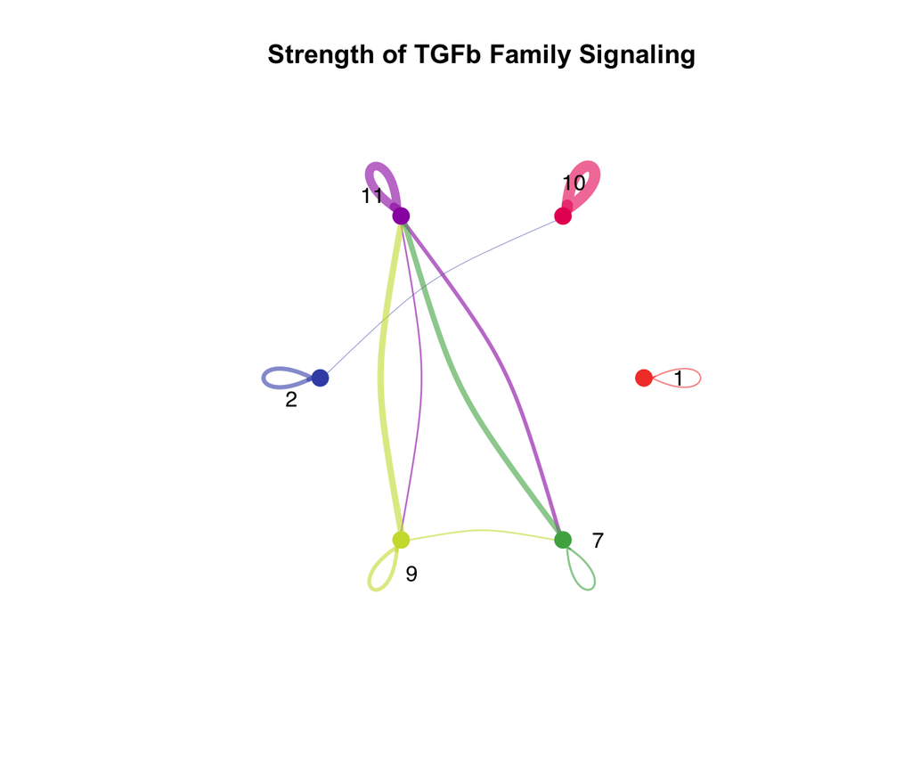

```r
plot_LR_cluster_net(
    db_C2C_score_list,complex_data$kept_db,
      LR_pair = c("Fgf1.Fgfr1","Fgf1.Fgfr2"),
      #LR_family=c("FGF","TGFb")
      cluster_use=c("1","10","11","2","9","7"),
      method_use = "strength",
      title="Strength of Fgf1-Fgfr1 and Fgf1-Fgfr2",
      mat_scale = TRUE,
    )

plot_LR_cluster_net(
    db_C2C_score_list,complex_data$kept_db,
      #LR_pair = c("Fgf1.Fgfr1","Fgf1.Fgfr2"),
      LR_family=c("TGFb"),
      cluster_use=c("1","10","11","2","9","7"),
      method_use = "strength",
      mat_scale = TRUE,
      weight.scale = TRUE
    )
```

Maybe you have noticed the title already. It can be auto-generated in some certain conditions, depending on the ‘method_use’, ‘LR_family’ and ‘LR_pair’. But also, we can mannually set the title using ‘title’ parameterm like the left figure.

Specifically, this function have two scale argments. The ‘mat_scale’ is used to scale raw score matrix, and the ‘weight.scale’ is used to control the chrod thickness. For more details, please see the document of The function.

### Chord Diagram

Chord diagram is also a good way to show the relationship between the sender and receiver. Escpecially, it display the clear relative strength between the clusters. Here, we show the two different chord diagrams, one for clusters and one for genes.

```
#> The '.' in the 'cluster' will be transformed to '_' in case of conflicting with LR
```

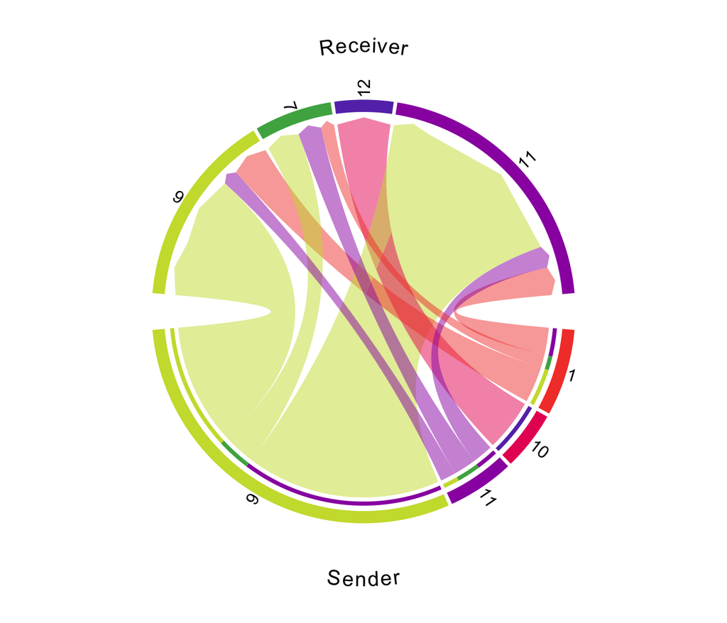

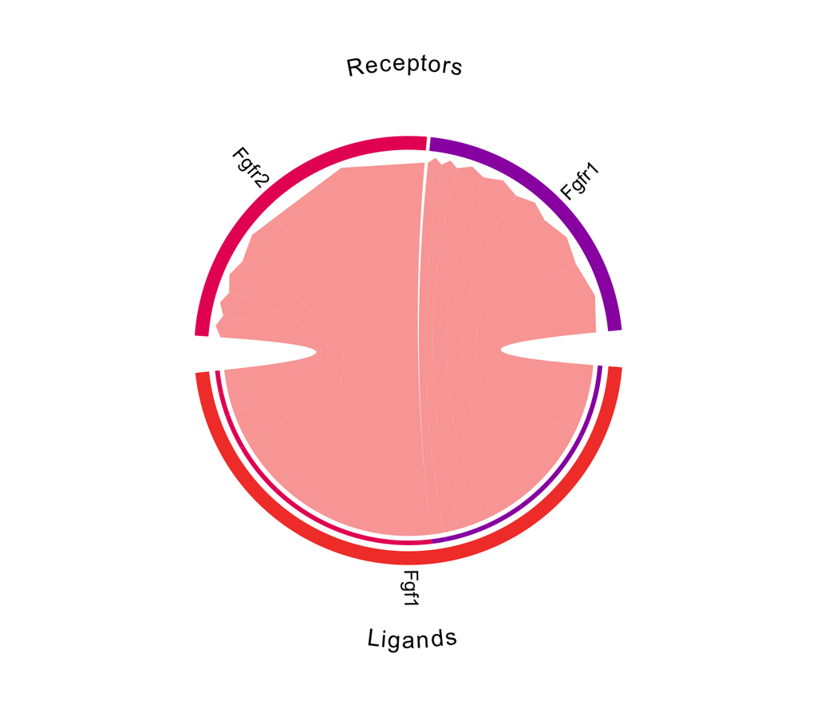

```r
plot_LR_cluster_chord(
    db_C2C_score_list,complex_data$kept_db,
      LR_pair = c("Fgf1.Fgfr1","Fgf1.Fgfr2"),
      #LR_family=c("FGF","TGFb")
      source_use=c("1","10","11","2","9"),
      target_use = c("7","9","11","12")
    )
plot_LR_gene_chord(
    db_C2C_score_list,complex_data$kept_db,
      LR_pair = c("Fgf1.Fgfr1","Fgf1.Fgfr2"),
      #LR_family=c("FGF","TGFb")
      source_use=c("1","10","11","2","9"),
      target_use = c("7","9","11","12")
    )
```

## The color of cluster identity

Finally, we talk about the cluster color crossing the pictures. As we expected, the colors should be consistent with the cluster identity. The good news is, all the cluster color can be assigned automatically. And if you give the same unfiltered raw C2C score list, it will be same. Even though some of them are not shown in the plot which are filtered by function parameters.

Here is an example.

```
#> The '.' in the 'cluster' will be transformed to '_' in case of conflicting with LR
```

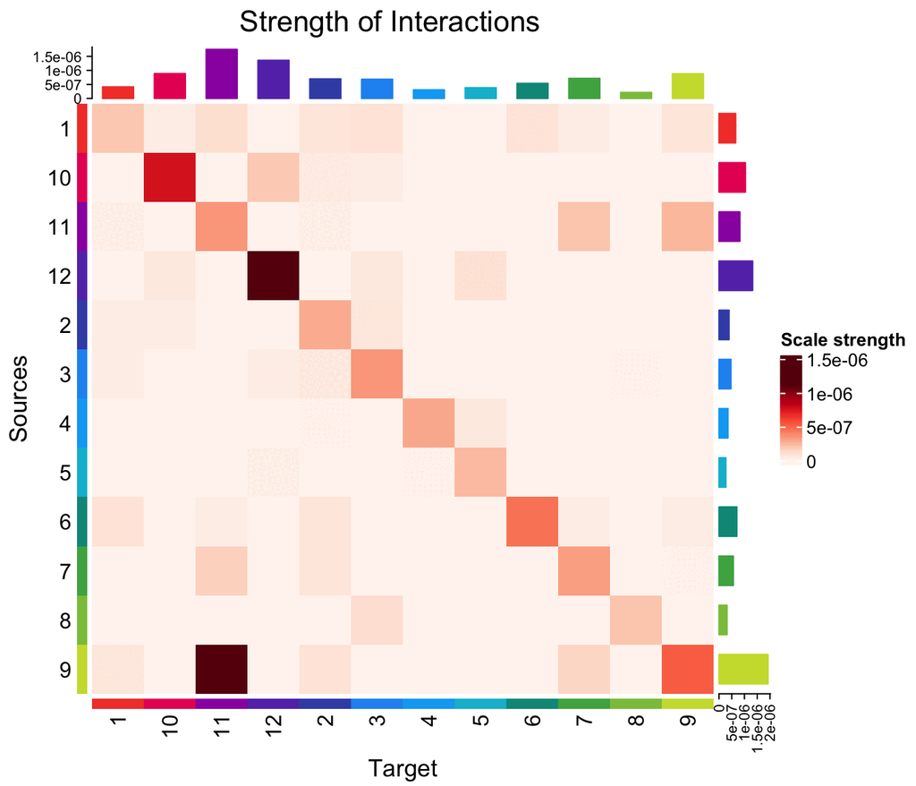

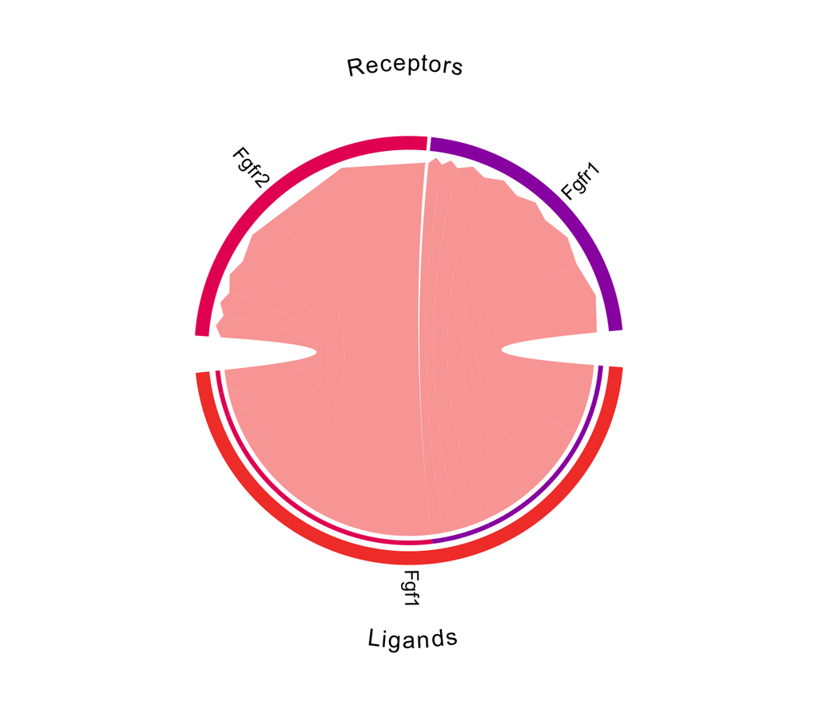

```r
plot_LR_cluster_heatmap(
  db_C2C_score_list,
  complex_data$kept_db,
  #LR_family = "TGFb",
  #LR_pair = c("Fgf1.Fgfr1","Fgf1.Fgfr2"),
  #source_use=c("1","10","11","2","9"),
  #target_use = c("7","9","11","12"),
  method_use="strength",
  normalize=TRUE,
  ht_col="Reds"
)
plot_LR_gene_chord(
    db_C2C_score_list,complex_data$kept_db,
      LR_pair = c("Fgf1.Fgfr1","Fgf1.Fgfr2"),
      #LR_family=c("FGF","TGFb")
      source_use=c("1","10","11","2","9"),
      target_use = c("7","9","11","12")
    )
```

The bad news is the colors will not be used in field projection over cluster info, because it is controlled by the Seurat. But we still have the solutions to keep them same by giving a named vector. The named color vector can be generated from spWAVE color assign function, or mannually assignment like below

```r
#using spWAVE color assign function
# c_col <- assign_clu_col_lite(db_C2C_score_list[[1]]$summary)
# c_col
#or mannually assign like
c_col <- c(
  "1"="#1f77b4",
  "2"="#ff7f0e",
  "3"="#2ca02c",
  "4"="#d62728",
  "5"="#9467bd",
  "6"="#8c564b",
  "7"="#e377c2",
  "8"="#7f7f7f",
  "9"="#bcbd22",
  "10"="#17becf",
  "11"="#aec7e8",
  "12"="#ffbb78"
)
# remember c_col must be a named vector

plot_field_direction2(brain_Fgf1,
            seurat_obj = brain,
            image="cluster",mode='grid',cols=c_col,arrow_color="yellow")
```

```
#> replace the existing one.
```

```
#> The '.' in the 'cluster' will be transformed to '_' in case of conflicting with LR
```

[figure not shown]

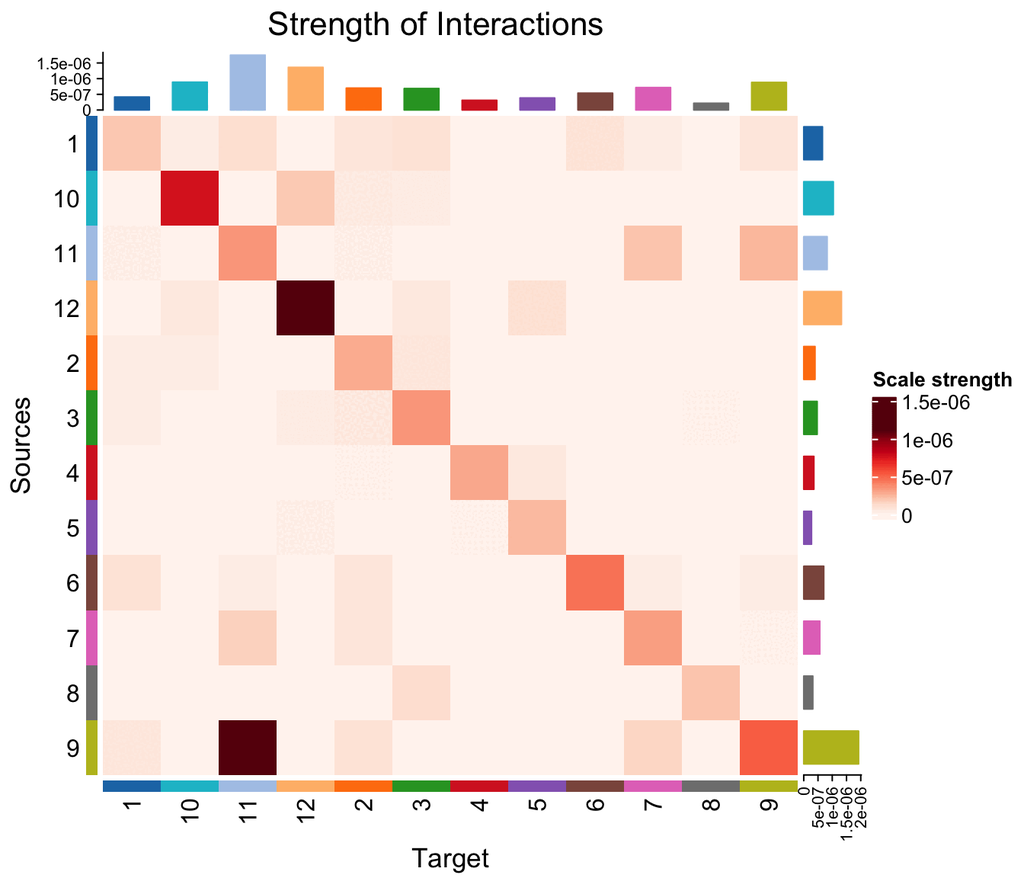

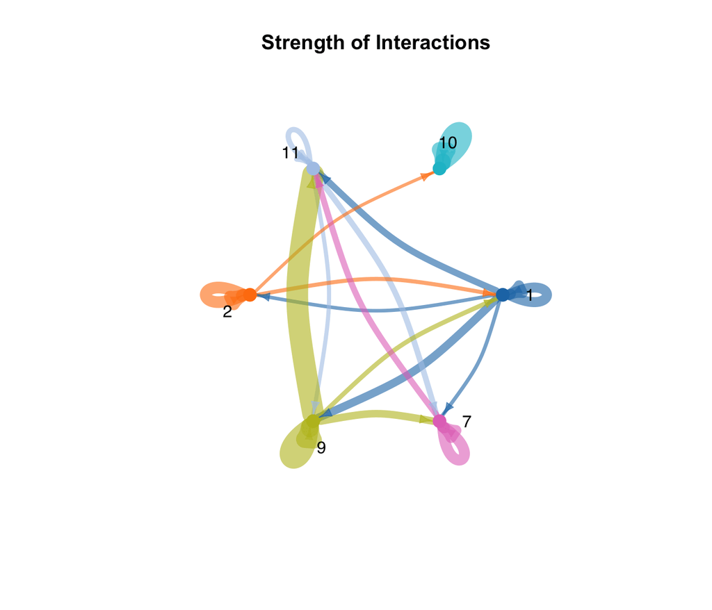

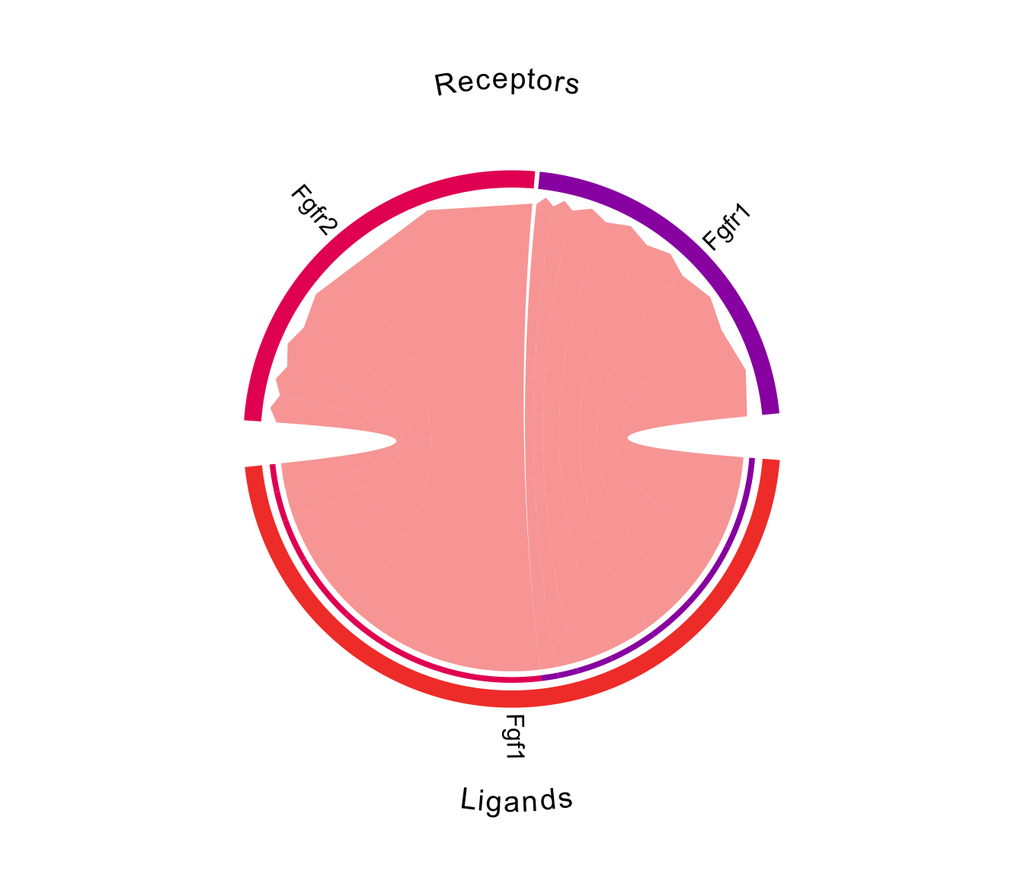

```r
plot_LR_cluster_heatmap(
  db_C2C_score_list,
  complex_data$kept_db,
  #LR_family = "TGFb",
  #LR_pair = c("Fgf1.Fgfr1","Fgf1.Fgfr2"),
  #source_use=c("1","10","11","2","9"),
  #target_use = c("7","9","11","12"),
  method_use="strength",
  normalize=TRUE,
  ht_col="Reds",
  cluster_color = c_col
)

plot_LR_cluster_net(
    db_C2C_score_list,complex_data$kept_db,
      LR_pair = c("Fgf1.Fgfr1","Fgf1.Fgfr2"),
      #LR_family=c("FGF","TGFb")
      cluster_use=c("1","10","11","2","9","7"),
      method_use = "strength",
      mat_scale = TRUE,
      cluster_color = c_col
    )

plot_LR_gene_chord(
    db_C2C_score_list,complex_data$kept_db,
      LR_pair = c("Fgf1.Fgfr1","Fgf1.Fgfr2"),
      #LR_family=c("FGF","TGFb")
      source_use=c("1","10","11","2","9"),
      target_use = c("7","9","11","12"),
      #** this plot colours by LR species (LR_color), not by cluster
    )
```

We will stop here, if you have any question, please check the document of function first, and then let us know if we can help you.